# Prosper Loan Dataset Findings

## by Soliman Seif

## Investigation Overview

> I am going to communicate the findings of the prosper Loan dataset by showing some visualizations with description. I will provide some details about the loans length, Lender yield, Effective yield, Estimated loss, and estimated return and their relation with category of the listing and the loan status

## Dataset Overview

> The dataset is available in https://s3.amazonaws.com/udacity-hosted-downloads/ud651/prosperLoanData.csv.

> This data set contains 113,937 loans with 81 variables on each loan, including loan amount, borrower rate (or interest ate), current loan status, borrower income, and many others.

```python
df_after200907['ListingCategory'] = df_after200907['ListingCategory (numeric)'].map({0:'Not Available', 1:'Debt Consolidation', 2:'Home Improvement', 3:'Business', 4:'Personal Loan', 5:'Student Use', 6:'Auto', 7:'Other', 8:'Baby&Adoption', 9:'Boat', 10:'Cosmetic Procedure', 11:'Engagement Ring', 12:'Green Loans', 13:'Household Expenses', 14:'Large Purchases', 15:'Medical/Dental', 16:'Motorcycle', 17:'RV', 18:'Taxes', 19:'Vacation', 20:'Wedding Loans'})
```

## Univariate Exploration

In this section I will explore below features

> - Term
> - LoanStatus
> - LenderYield
> - EstimatedEffectiveYield
> - EstimatedLoss
> - EstimatedReturn
> - ListingCategory (numeric)

### Univariate Exploration: Term Feature

Definition: The length of the loan expressed in months.

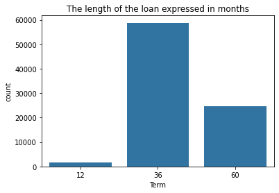

```python
sb.countplot(data = df_after200907, x = 'Term', color = default_color).set_title('The length of the loan expressed in months');
```

> - The Term parameter have 3 possible values (12, 36 , 60) Months
> - Most of loans are 36 Months loans

### Univariate Exploration: LoanStatus Feature

Definition: The current status of the loan: Cancelled, Chargedoff, Completed, Current, Defaulted, FinalPaymentInProgress, PastDue. The PastDue status will be accompanied by a delinquency bucket.

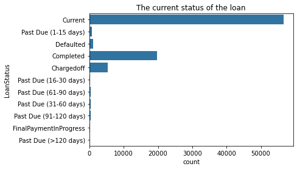

```python
sb.countplot(data = df_after200907, y = 'LoanStatus', color = default_color).set_title('The current status of the loan');
```

> - From this plot you can see that most of the loans are in current state.

### Univariate Exploration: LenderYield Feature

Definition: The Lender yield on the loan. Lender yield is equal to the interest rate on the loan less the servicing fee.

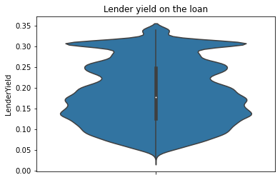

```python
sb.violinplot(data = df_after200907, y = 'LenderYield').set_title('Lender yield on the loan');
```

### Univariate Exploration: EstimatedEffectiveYield Feature

Definition: Effective yield is equal to the borrower interest rate (i) minus the servicing fee rate, (ii) minus estimated uncollected interest on charge-offs, (iii) plus estimated collected late fees. Applicable for loans originated after July 2009.

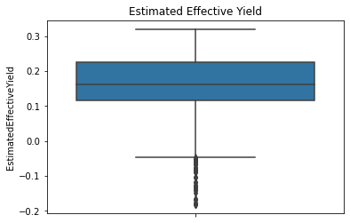

```python
sb.boxplot(data = df_after200907, y = 'EstimatedEffectiveYield').set_title('Estimated Effective Yield');
```

> - Mean: 0.168677
> - 25% quartile : 0.11567
> - 75% quartile : 0.2243

### Univariate Exploration: EstimatedLoss Feature

Definition: Estimated loss is the estimated principal loss on charge-offs. Applicable for loans originated after July 2009.

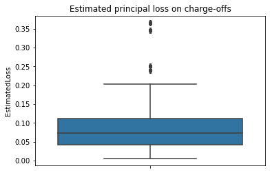

```python
sb.boxplot(data = df_after200907, y = 'EstimatedLoss').set_title('Estimated principal loss on charge-offs');
```

> - The estimated loss mean around 8%

### Univariate Exploration: EstimatedReturn Feature

Definition: The estimated return assigned to the listing at the time it was created. Estimated return is the difference between the Estimated Effective Yield and the Estimated Loss Rate. Applicable for loans originated after July 2009.

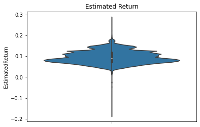

```python
sb.violinplot(data = df_after200907, y = 'EstimatedReturn').set_title('Estimated Return');
```

> - The average EstimatedReturn is 9.6%

### Univariate Exploration: ListingCategory Feature

Definition: The category of the listing that the borrower selected when posting their listing: 0 - Not Available, 1 - Debt Consolidation, 2 - Home Improvement, 3 - Business, 4 - Personal Loan, 5 - Student Use, 6 - Auto, 7- Other, 8 - Baby&Adoption, 9 - Boat, 10 - Cosmetic Procedure, 11 - Engagement Ring, 12 - Green Loans, 13 - Household Expenses, 14 - Large Purchases, 15 - Medical/Dental, 16 - Motorcycle, 17 - RV, 18 - Taxes, 19 - Vacation, 20 - Wedding Loans

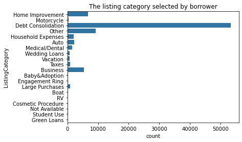

```python
sb.countplot(data = df_after200907, y = 'ListingCategory', color = default_color).set_title('The listing category selected by borrower');
```

> - from the count plot for the ListingCategory values you can find that most of browers selected Debt Consolidation option

## Bivariate Exploration

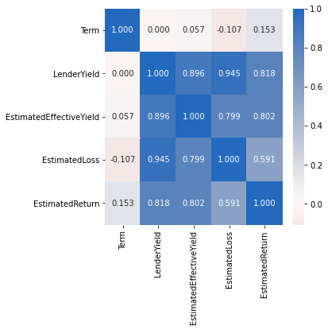

```python
# correlation plot
plt.figure(figsize = [5, 5]);
sb.heatmap(df_after200907[allNumericVars].corr(), annot = True, fmt = '.3f', cmap = 'vlag_r', center = 0, xticklabels=True, yticklabels=True);
```

> the correlation cofficients indicate there might be correlations between the following pairs of variables:
> - LenderYield and EstimatedEffectiveYield and EstimatedLoss and EstimatedReturn

### Bivariate Exploration: Loans count for each Term and ListingCategory

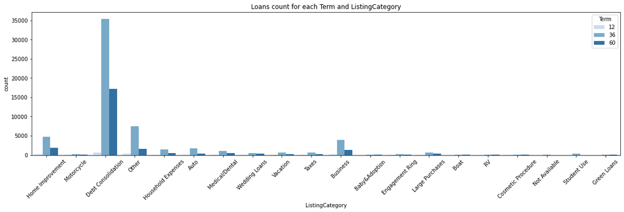

```python
plt.figure(figsize = [20, 5]);
plt.title('Loans count for each Term and ListingCategory');
sb.countplot(data = df_after200907, x = 'ListingCategory', hue = 'Term', palette = 'Blues');
plt.xticks(rotation=45);
```

> - The above plot show that the 36 month term is the highest for all ListingCategory
> - the ListingCategory 'Debit Consolidation' is the most popular with Term 36 Month.

### Bivariate Exploration: Loans count categorized by ListingCategory and IsBorrowerHomeowner

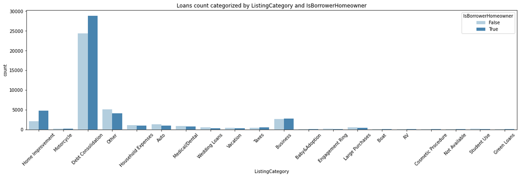

```python
plt.figure(figsize = [20, 5]);
plt.title('Loans count categorized by ListingCategory and IsBorrowerHomeowner');
sb.countplot(data = df_after200907, x = 'ListingCategory', hue = 'IsBorrowerHomeowner', palette = 'Blues');
plt.xticks(rotation=45);
```

> - This plot showing that most of the Debit Consolidation ListingCategory are home owners

### Bivariate Exploration: Loans count categorized by ListingCategory and LoanStatus

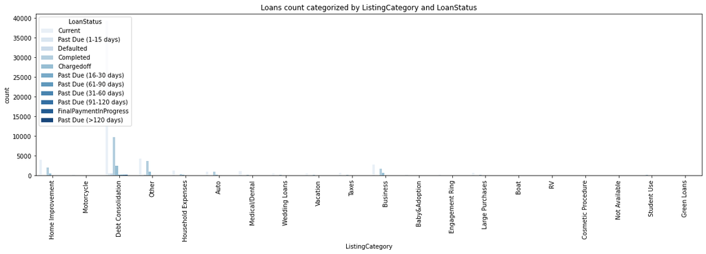

```python
plt.figure(figsize = [20, 5]);
plt.title('Loans count categorized by ListingCategory and LoanStatus');
sb.countplot(data = df_after200907, x = 'ListingCategory', hue = 'LoanStatus', palette = 'Blues');
plt.xticks(rotation=90);
```

> - The plot showing that most of Debt Consolidation loan status is Current

### Bivariate Exploration: Loans count categorized by LoanStatus and Term

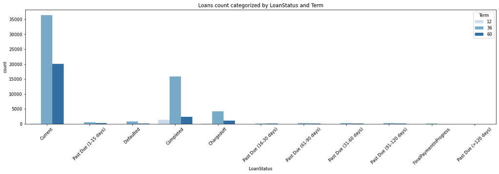

```python
plt.figure(figsize = [20, 5]);
plt.title('Loans count categorized by LoanStatus and Term');
sb.countplot(data = df_after200907, x = 'LoanStatus', hue = 'Term', palette = 'Blues');
plt.xticks(rotation=45);
```

> From the above plot you can find that :
> - most of the loans in Current status are 36 months and 60 months
> - 12 months loans are almost in complete state.

## Multivariate Exploration

### Multivariate Exploration: LoanStatus vs LenderYield vs EstimatedEffectiveYield

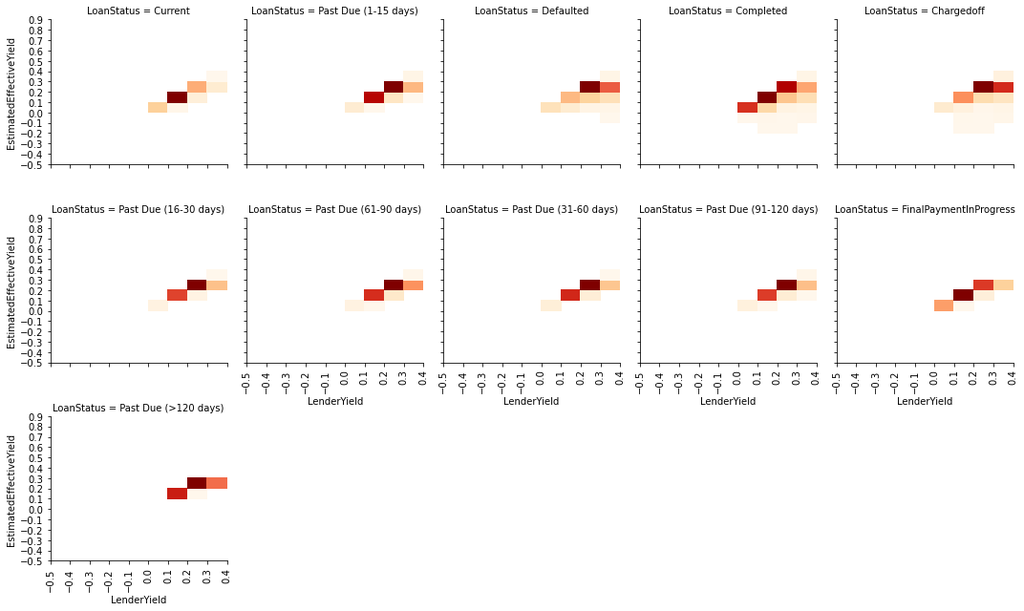

```python
g = sb.FacetGrid(data = df_after200907, col = 'LoanStatus', col_wrap = 5, height = 3);
g.map(myHist2D, 'LenderYield', 'EstimatedEffectiveYield', color = 'OrRd');
g.set_xlabels('LenderYield');
g.set_ylabels('EstimatedEffectiveYield');
```

### Multivariate Exploration: ListingCategory vs EstimatedLoss vs EstimatedReturn

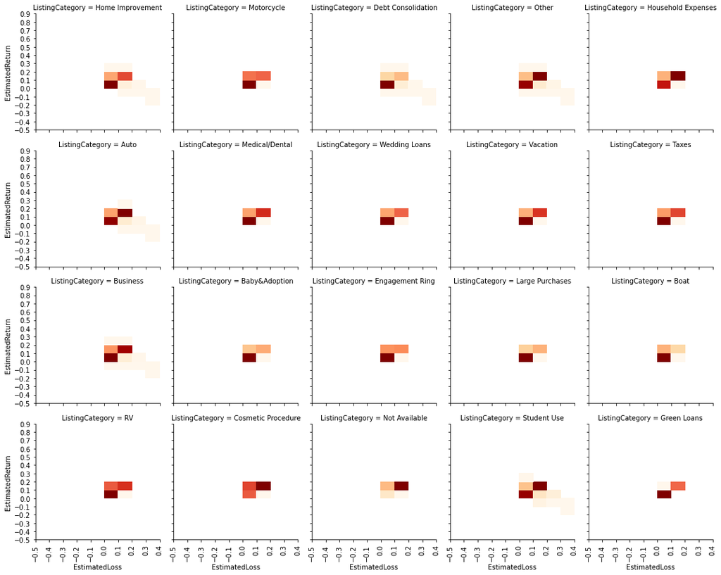

```python
g = sb.FacetGrid(data = df_after200907, col = 'ListingCategory', col_wrap = 5, height = 3)
g.map(myHist2D, 'EstimatedLoss', 'EstimatedReturn', color = 'OrRd');
g.set_xlabels('EstimatedLoss');
g.set_ylabels('EstimatedReturn');
```

> from the above plot you can find that
> - Loans with Listing Category Home Improvement , Debit Consolidation, Other, Auto, Business, students Use have higher estimated return and estimated loss